# Building A K-Means Algorithm

The purpose of this project is to build a k-means clustering algorithm from scratch, then compare the result to the kmeans() function built in to R. The data was provided by my instructor Dr. Cliff Baldwin.

```r
# Read in the data
data = read.csv("KMeansData_Branco.csv", header = FALSE) # The data doesn't have a header.
# check the data
head(data)
```

|  | V1 | V2 |
| --- | --- | --- |
| 1 | 0.4429445 | 0.7071066 |
| 2 | 0.3514473 | 0.4426592 |
| 3 | 0.4975926 | 0.7999334 |
| 4 | 0.4501654 | 0.8270090 |
| 5 | 0.5940498 | 0.3003777 |
| 6 | 0.6268217 | 0.7995863 |

```r
tail(data)
```

|  | V1 | V2 |
| --- | --- | --- |
| 528 | 9.690925 | 1.4563808 |
| 529 | 9.295511 | 0.6278095 |
| 530 | 9.043804 | 1.1946803 |
| 531 | 9.387565 | 1.3039081 |
| 532 | 9.744572 | 1.3382664 |
| 533 | 9.549374 | 1.5743642 |

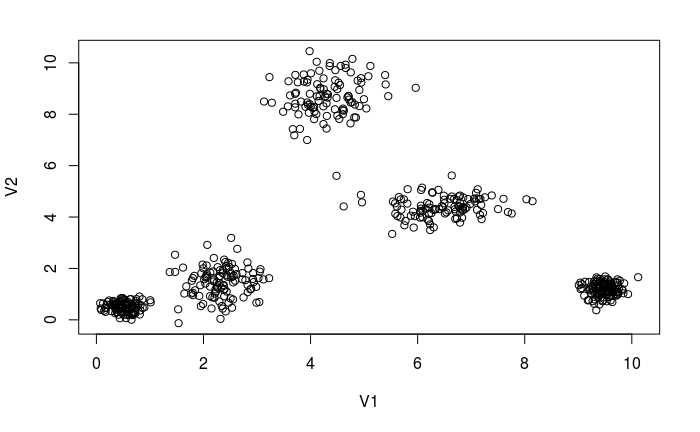

```r
# Plot the data to get an idea of what it looks like.
plot(data)
```

```r
# From this plot, it is fairly clear that there are probably around five clusters.
```

```r
# Write the function from scratch
my_k_means <- function(data, K){ # Have inputs of the data and of the K desired.
  iteration <- 0 # When iteration = 0, the clusters will be changing. When the clusters stop changing, then iteration becomes 1 and the loop breaks.
  #if (exists("iteration") == FALSE ) {iteration <- 0}  # This if statement

  # Making the initial clusters
  # One way to get clusters is to make them random points from the data set, but this doesn't always work the way we want (3 cluster centers close to each other, for example)
  x_numbers <- seq(from=1, to=533, by=1)
  clus_points <- sample(x_numbers, size=K, replace=TRUE)
  clusters <- c()
  for (i in 1:nrow(data)) {
    for (j in clus_points) {
      if (i == j) {
        clusters <- rbind(clusters,data[i,])
      }
    }
  }
  # I have also tried making the clusters the first K points in the data set, but that doesn't generally yield good results for K > 5
  #clusters <- data[1:K, ]

  # Calculate the Euclidean Distance between each point and the clusters.
  # Put Euclidean Distance in a function.
  ed <- function(x,y) {
    sqrt(sum((x - y) ^ 2)) # Take the Euclidean Distance from two vectors.
  }
  while (iteration <= 1) {
    clus_num = c() # Make these variables for later
    result = c()

    old_clusters <- clusters # Memory of the clusters will allow us to compare to see if the clusters have changed.

    get_distance <- function (data) { # Made this a function to use later on, never did. Kept it as a function though.
      for(i in 1:nrow(data)) { # Iterate over all points in data
        point <- data[i,] # Data point
        for (j in 1:nrow(clusters)) { # Iterate over each cluster
          clus <- clusters[j,] # cluster point
          result[j] <- ed(point,clus) # Get euclidean distance from each cluster to the point
        }
      clus_num[i] <- which(result==min(result)) # A list of every cluster number that is closest to each point.
      }
      return(clus_num) # Output the array of closest clusters by number
    }

    clus_num <- get_distance(data) # Array of closest clusters by number

    num_data <- cbind(data, clus_num) # Add another collumn to the data that has the closest cluster number.

    # Assign colors to each cluster
    clus_num <- replace(clus_num, clus_num == 1, "black")
    clus_num <- replace(clus_num, clus_num == 2, "blue")
    clus_num <- replace(clus_num, clus_num == 3, "red")
    clus_num <- replace(clus_num, clus_num == 4, "gray")
    clus_num <- replace(clus_num, clus_num == 5, "green")
    clus_num <- replace(clus_num, clus_num == 6, "orange")
    clus_num <- replace(clus_num, clus_num == 7, "pink")
    clus_num <- replace(clus_num, clus_num == 8, "seagreen") # Looked up a list of colors. My girlfriend picked this one out.
    clus_num <- replace(clus_num, clus_num == 9, "steelblue") # I picked this one. It sounds cool
    clus_num <- replace(clus_num, clus_num == 10, "violet")

    newdata <- cbind(num_data, clus_num) # Assign the cluster by color to each point. This color represents the closest cluster to the point.

    # Change the cluster centers by getting the average point from each point.
    # Start at zero
    clus_1_x <- 0
    clus_1_y <- 0
    clus_2_x <- 0
    clus_2_y <- 0
    clus_3_x <- 0
    clus_3_y <- 0
    clus_4_x <- 0
    clus_4_y <- 0
    clus_5_x <- 0
    clus_5_y <- 0
    clus_6_x <- 0
    clus_6_y <- 0
    clus_7_x <- 0
    clus_7_y <- 0
    clus_8_x <- 0
    clus_8_y <- 0
    clus_9_x <- 0
    clus_9_y <- 0
    clus_10_x <- 0
    clus_10_y <- 0

    # Begin counter at zero
    n_c1 <- 0
    n_c2 <- 0
    n_c3 <- 0
    n_c4 <- 0
    n_c5 <- 0
    n_c6 <- 0
    n_c7 <- 0
    n_c8 <- 0
    n_c9 <- 0
    n_c10 <- 0

    # For each possible cluster, add up the x-values and y-values of each point within that cluster.
    # Also, find the number of points in that cluster.
    # NOTE: THIS FAILS IF A CLUSTER HAS NO POINTS!!!
    for (i in 1:nrow(newdata)) {
      if (num_data[i,3] == 1) {
        clus_1_x <- clus_1_x + newdata[i,1] # x-coordinate
        clus_1_y <- clus_1_y + newdata[i,2] # y-coordinate
        n_c1 <- n_c1 + 1 # number
      }
      if (num_data[i,3] == 2) {
        clus_2_x <- clus_2_x + newdata[i,1] # x-coordinate
        clus_2_y <- clus_2_y + newdata[i,2] # y-coordinate
        n_c2 <- n_c2 + 1 # number
      }
      if (num_data[i,3] == 3) {
        clus_3_x <- clus_3_x + newdata[i,1] # x-coordinate
        clus_3_y <- clus_3_y + newdata[i,2] # y-coordinate
        n_c3 <- n_c3 + 1 # number
      }
      if (num_data[i,3] == 4) {
        clus_4_x <- clus_4_x + newdata[i,1] # x-coordinate
        clus_4_y <- clus_4_y + newdata[i,2] # y-coordinate
        n_c4 <- n_c4 + 1 # number
      }
      if (num_data[i,3] == 5) {
        clus_5_x <- clus_5_x + newdata[i,1] # x-coordinate
        clus_5_y <- clus_5_y + newdata[i,2] # y-coordinate
        n_c5 <- n_c5 + 1 # number
      }
      if (num_data[i,3] == 6) {
        clus_6_x <- clus_6_x + newdata[i,1] # x-coordinate
        clus_6_y <- clus_6_y + newdata[i,2] # y-coordinate
        n_c6 <- n_c6 + 1 #number
      }
      if (num_data[i,3] == 7) {
        clus_7_x <- clus_7_x + newdata[i,1] # x-coordinate
        clus_7_y <- clus_7_y + newdata[i,2] # y-coordinate
        n_c7 <- n_c7 + 1 # number
      }
      if (num_data[i,3] == 8) {
        clus_8_x <- clus_8_x + newdata[i,1] # x-coordinate
        clus_8_y <- clus_8_y + newdata[i,2] # y-coordinate
        n_c8 <- n_c8 + 1 # number
      }
      if (num_data[i,3] == 9) {
        clus_9_x <- clus_9_x + newdata[i,1] # x-coordinate
        clus_9_y <- clus_9_y + newdata[i,2] # y-coordinate
        n_c9 <- n_c9 + 1 # number
      }
      if (num_data[i,3] == 10) {
        clus_10_x <- clus_10_x + newdata[i,1] # x-coordinate
        clus_10_y <- clus_10_y + newdata[i,2] # y-coordinate
        n_c10 <- n_c10 + 1 # number
      }
    }

    # For each, take the average x and y values then replace the old clusters with the new ones.
    # I did this separate for each possible K and let me tell you, since for some reason cut and paste doesn't always work for my rstudio, most of this is by hand.
    # There are probably better ways to do it that are more efficient. I'm just glad it works.
    if (K == 1) {
      clus_1_x <- clus_1_x / n_c1
      clus_1_y <- clus_1_y / n_c1
      clusters[1,1] <- clus_1_x
      clusters[1,2] <- clus_1_y
    }
```

```r
    if (K == 2) {
      clus_1_x <- clus_1_x / n_c1
      clus_1_y <- clus_1_y / n_c1
      clus_2_x <- clus_2_x / n_c2
      clus_2_y <- clus_2_y / n_c2

      clusters[1,1] <- clus_1_x
      clusters[1,2] <- clus_1_y
      clusters[2,1] <- clus_2_x
      clusters[2,2] <- clus_2_y
    }

    if (K == 3) {
      clus_1_x <- clus_1_x / n_c1
      clus_1_y <- clus_1_y / n_c1
      clus_2_x <- clus_2_x / n_c2
      clus_2_y <- clus_2_y / n_c2
      clus_3_x <- clus_3_x / n_c3
      clus_3_y <- clus_3_y / n_c3

      clusters[1,1] <- clus_1_x
      clusters[1,2] <- clus_1_y
      clusters[2,1] <- clus_2_x
      clusters[2,2] <- clus_2_y
      clusters[3,1] <- clus_3_x
      clusters[3,2] <- clus_3_y
    }

    if (K == 4) {
      clus_1_x <- clus_1_x / n_c1
      clus_1_y <- clus_1_y / n_c1
      clus_2_x <- clus_2_x / n_c2
      clus_2_y <- clus_2_y / n_c2
      clus_3_x <- clus_3_x / n_c3
      clus_3_y <- clus_3_y / n_c3
      clus_4_x <- clus_4_x / n_c4
      clus_4_y <- clus_4_y / n_c4

      clusters[1,1] <- clus_1_x
      clusters[1,2] <- clus_1_y
      clusters[2,1] <- clus_2_x
      clusters[2,2] <- clus_2_y
      clusters[3,1] <- clus_3_x
      clusters[3,2] <- clus_3_y
      clusters[4,1] <- clus_4_x
      clusters[4,2] <- clus_4_y
    }

    if (K == 5) {
      clus_1_x <- clus_1_x / n_c1
      clus_1_y <- clus_1_y / n_c1
      clus_2_x <- clus_2_x / n_c2
      clus_2_y <- clus_2_y / n_c2
      clus_3_x <- clus_3_x / n_c3
      clus_3_y <- clus_3_y / n_c3
      clus_4_x <- clus_4_x / n_c4
      clus_4_y <- clus_4_y / n_c4
      clus_5_x <- clus_5_x / n_c5
      clus_5_y <- clus_5_y / n_c5

      clusters[1,1] <- clus_1_x
      clusters[1,2] <- clus_1_y
      clusters[2,1] <- clus_2_x
      clusters[2,2] <- clus_2_y
      clusters[3,1] <- clus_3_x
      clusters[3,2] <- clus_3_y
      clusters[4,1] <- clus_4_x
      clusters[4,2] <- clus_4_y
      clusters[5,1] <- clus_5_x
      clusters[5,2] <- clus_5_y
    }

    if (K == 6) {
      clus_1_x <- clus_1_x / n_c1
      clus_1_y <- clus_1_y / n_c1
      clus_2_x <- clus_2_x / n_c2
      clus_2_y <- clus_2_y / n_c2
      clus_3_x <- clus_3_x / n_c3
      clus_3_y <- clus_3_y / n_c3
      clus_4_x <- clus_4_x / n_c4
      clus_4_y <- clus_4_y / n_c4
      clus_5_x <- clus_5_x / n_c5
      clus_5_y <- clus_5_y / n_c5
      clus_6_x <- clus_6_x / n_c6
      clus_6_y <- clus_6_y / n_c6

      clusters[1,1] <- clus_1_x
      clusters[1,2] <- clus_1_y
      clusters[2,1] <- clus_2_x
      clusters[2,2] <- clus_2_y
      clusters[3,1] <- clus_3_x
      clusters[3,2] <- clus_3_y
      clusters[4,1] <- clus_4_x
      clusters[4,2] <- clus_4_y
      clusters[5,1] <- clus_5_x
      clusters[5,2] <- clus_5_y
      clusters[6,1] <- clus_6_x
      clusters[6,2] <- clus_6_y
    }

    if (K == 7) {
      clus_1_x <- clus_1_x / n_c1
      clus_1_y <- clus_1_y / n_c1
      clus_2_x <- clus_2_x / n_c2
      clus_2_y <- clus_2_y / n_c2
      clus_3_x <- clus_3_x / n_c3
      clus_3_y <- clus_3_y / n_c3
      clus_4_x <- clus_4_x / n_c4
      clus_4_y <- clus_4_y / n_c4
      clus_5_x <- clus_5_x / n_c5
      clus_5_y <- clus_5_y / n_c5
      clus_6_x <- clus_6_x / n_c6
      clus_6_y <- clus_6_y / n_c6
      clus_7_x <- clus_7_x / n_c7
      clus_7_y <- clus_7_y / n_c7

      clusters[1,1] <- clus_1_x
      clusters[1,2] <- clus_1_y
      clusters[2,1] <- clus_2_x
      clusters[2,2] <- clus_2_y
      clusters[3,1] <- clus_3_x
      clusters[3,2] <- clus_3_y
      clusters[4,1] <- clus_4_x
      clusters[4,2] <- clus_4_y
      clusters[5,1] <- clus_5_x
      clusters[5,2] <- clus_5_y
      clusters[6,1] <- clus_6_x
      clusters[6,2] <- clus_6_y
      clusters[7,1] <- clus_7_x
      clusters[7,2] <- clus_7_y
    }

    if (K == 8) {
      clus_1_x <- clus_1_x / n_c1
      clus_1_y <- clus_1_y / n_c1
      clus_2_x <- clus_2_x / n_c2
      clus_2_y <- clus_2_y / n_c2
      clus_3_x <- clus_3_x / n_c3
      clus_3_y <- clus_3_y / n_c3
      clus_4_x <- clus_4_x / n_c4
      clus_4_y <- clus_4_y / n_c4
      clus_5_x <- clus_5_x / n_c5
      clus_5_y <- clus_5_y / n_c5
      clus_6_x <- clus_6_x / n_c6
      clus_6_y <- clus_6_y / n_c6
      clus_7_x <- clus_7_x / n_c7
      clus_7_y <- clus_7_y / n_c7
      clus_8_x <- clus_8_x / n_c8
      clus_8_y <- clus_8_y / n_c8

      clusters[1,1] <- clus_1_x
      clusters[1,2] <- clus_1_y
      clusters[2,1] <- clus_2_x
      clusters[2,2] <- clus_2_y
      clusters[3,1] <- clus_3_x
      clusters[3,2] <- clus_3_y
      clusters[4,1] <- clus_4_x
      clusters[4,2] <- clus_4_y
      clusters[5,1] <- clus_5_x
      clusters[5,2] <- clus_5_y
      clusters[6,1] <- clus_6_x
      clusters[6,2] <- clus_6_y
      clusters[7,1] <- clus_7_x
      clusters[7,2] <- clus_7_y
      clusters[8,1] <- clus_8_x
      clusters[8,2] <- clus_8_y
    }

    if (K == 9) {
      clus_1_x <- clus_1_x / n_c1
      clus_1_y <- clus_1_y / n_c1
      clus_2_x <- clus_2_x / n_c2
      clus_2_y <- clus_2_y / n_c2
      clus_3_x <- clus_3_x / n_c3
      clus_3_y <- clus_3_y / n_c3
      clus_4_x <- clus_4_x / n_c4
      clus_4_y <- clus_4_y / n_c4
      clus_5_x <- clus_5_x / n_c5
      clus_5_y <- clus_5_y / n_c5
      clus_6_x <- clus_6_x / n_c6
      clus_6_y <- clus_6_y / n_c6
      clus_7_x <- clus_7_x / n_c7
      clus_7_y <- clus_7_y / n_c7
      clus_8_x <- clus_8_x / n_c8
      clus_8_y <- clus_8_y / n_c8
      clus_9_x <- clus_9_x / n_c9
      clus_9_y <- clus_9_y / n_c9

      clusters[1,1] <- clus_1_x
      clusters[1,2] <- clus_1_y
      clusters[2,1] <- clus_2_x
      clusters[2,2] <- clus_2_y
      clusters[3,1] <- clus_3_x
      clusters[3,2] <- clus_3_y
      clusters[4,1] <- clus_4_x
      clusters[4,2] <- clus_4_y
      clusters[5,1] <- clus_5_x
      clusters[5,2] <- clus_5_y
      clusters[6,1] <- clus_6_x
      clusters[6,2] <- clus_6_y
      clusters[7,1] <- clus_7_x
      clusters[7,2] <- clus_7_y
      clusters[8,1] <- clus_8_x
      clusters[8,2] <- clus_8_y
      clusters[9,1] <- clus_9_x
      clusters[9,2] <- clus_9_y
    }
```

```r
    if (K == 10) {
      clus_1_x <- clus_1_x / n_c1
      clus_1_y <- clus_1_y / n_c1
      clus_2_x <- clus_2_x / n_c2
      clus_2_y <- clus_2_y / n_c2
      clus_3_x <- clus_3_x / n_c3
      clus_3_y <- clus_3_y / n_c3
      clus_4_x <- clus_4_x / n_c4
      clus_4_y <- clus_4_y / n_c4
      clus_5_x <- clus_5_x / n_c5
      clus_5_y <- clus_5_y / n_c5
      clus_6_x <- clus_6_x / n_c6
      clus_6_y <- clus_6_y / n_c6
      clus_7_x <- clus_7_x / n_c7
      clus_7_y <- clus_7_y / n_c7
      clus_8_x <- clus_8_x / n_c8
      clus_8_y <- clus_8_y / n_c8
      clus_9_x <- clus_9_x / n_c9
      clus_9_y <- clus_9_y / n_c9
      clus_10_x <- clus_10_x / n_c10
      clus_10_y <- clus_10_y / n_c10

      clusters[1,1] <- clus_1_x
      clusters[1,2] <- clus_1_y
      clusters[2,1] <- clus_2_x
      clusters[2,2] <- clus_2_y
      clusters[3,1] <- clus_3_x
      clusters[3,2] <- clus_3_y
      clusters[4,1] <- clus_4_x
      clusters[4,2] <- clus_4_y
      clusters[5,1] <- clus_5_x
      clusters[5,2] <- clus_5_y
      clusters[6,1] <- clus_6_x
      clusters[6,2] <- clus_6_y
      clusters[7,1] <- clus_7_x
      clusters[7,2] <- clus_7_y
      clusters[8,1] <- clus_8_x
      clusters[8,2] <- clus_8_y
      clusters[9,1] <- clus_9_x
      clusters[9,2] <- clus_9_y
      clusters[10,1] <- clus_10_x
      clusters[10,2] <- clus_10_y
    }

    if (identical(clusters, old_clusters)) { # Check to see if the clusters are the same as the last iteration.
      iteration <- iteration + 1 # If the clusters are the same, set iteration to 1, letting the loop end after this iteration.
    }

    # plot(data, col = clus_num) # plot the data with the color of each point being what it was assigned a while back in the loop.
    # points(clusters,pch=16, col = "yellow")


    #So, for your own purposes, you can uncomment the two above lines and it will plot every step of the graphs. This is...not ideal for an R-Notebook presentation but running it     in the actual R code is interesting, as you can see the clusters moving as the distances are recalculated.
  }

  clus_num_dist <- c()

  for(i in 1:nrow(data)) { # Iterate over all points in data
    point <- data[i,] # point
    for (j in 1:nrow(clusters)) { # Iterate over each cluster
      clus <- clusters[j,] # cluster
      result[j] <- ed(point,clus) # Get euclidean distance from each cluster to the point
    }
    clus_num_dist <- cbind(clus_num_dist, result[which(result==min(result))]) # A list of the distance between each point and its closest cluster.
  }
  return(sum(clus_num_dist)) # the K-means function returns the sum of the distances between each point and its closest cluster, after iterating until the clusters remain unchanged.
}
```

I recognize that the function I wrote is extremely inefficient, however I want to stress that it’s not about doing it efficiently, but rather knowing what the function is doing. At this point, I don’t have the most experience in R, and so I use mostly python methods. The function takes in the data and the number of clusters. I will use the function that I built and find the elbow graph for K between one and ten.

```r
elbow_graph <- function(data) { # create an elbow graph. Put it in a function for practice.
  K <- c(1,2,3,4,5,6,7,8,9,10) # K can be from 1 to 10 (my function does not allow K > 10)
  SS <- c() # empty array for the sum of squares for each K
  for (i in K) { # for each K
    SS[i] <- my_k_means(data,i) # find the sum of the distances between each point and the closest cluster.
  }
  plot(K,SS) # Plot K vs SS
  return(SS) # Print out SS so that I can see.
}
```

Now that those functions are done, we need to plot the elbow graph. I will plot the graph for both my function and the built in kmeans() function, just to compare.

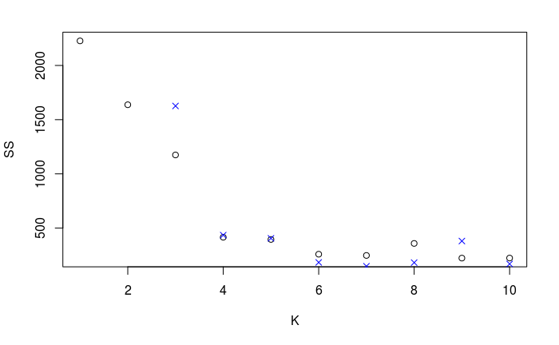

```r
SS <- elbow_graph(data) # Run. Sometimes it returns an error, so running it again is best.
SS_real <- c()
K <- c(1,2,3,4,5,6,7,8,9,10) # K can be from 1 to 10 (my function does not allow K > 10)
for (i in K) {
  SS_real[i] <- kmeans(data,i)$tot.withinss
}
points(K,SS_real, pch = 4, col = "blue") # Put the "real" k-means on the graph
```

```r
print(SS_real - SS) # Difference of my SS and their SS
```

```
 [1] 8147.59264 4897.18867  451.83113   19.44173   10.25610  -75.56597  -99.50287 -176.83210  157.39477  -54.27679
```

```r
compare <- cbind(SS_real,SS)
```

The graph shows that we have around four or five clusters. Now, let’s see how accurate we really are.

```r
# Now, to compute the accuracy
# A function that utilizes vectorization to compute the accuracy statistic
accuracy <- function(test_data){
  # Count correct when the prediction matches the test data
  correct = length(which(test_data[,ncol(test_data)-1] == test_data[,ncol(test_data)]))

  # Compute the percentage correct
  accu = correct/nrow(test_data) * 100
  return(accu)
}
accuracy(compare) # According to this, the accuracy of this function is 0, which makes sense since none of the points are the same.
```

```
[1] 0
```

```r
# However, some points according to the graph are very close, so I will use the following function to compute accuracy of each SS.
accuracy <- function(test_data,real_data) { # This function is meant to calculate accuracy according to the following formula:

  #                                        measured value - accepted value
  #                            accuracy = --------------------------------- * 100 %
  #                                                accepted value

  acc <- c() # Make an empty array
  for (i in 1:length(real_data)) {
    acc[i] <- abs(test_data[i] - real_data[i]) / real_data[i] * 100 # Compute the accuracy of each sum of squares
  }
  return(mean(acc)) # average value of all sums of squares
}
accuracy(SS,SS_real)
```

```
[1] 46.69957
```

So, as we can see, my function built from the ground up is…not very accurate. The idea behind this project wasn’t so much as to get it right as it was to learn how the function works. Now that I have built one myself, I have a better understanding of what the kmeans() function is doing and the applications it can be used for.

Just as a bonus, let’s just focus on five clusters and see how accurate my function is.

```r
abs(SS[5] - SS_real[5]) / SS_real[5] * 100 # Compute the accuracy of just K=5.
```

```
[1] 2.527578
```

My function seems to do well when K is close to the “true” number, in this case 5. In some cases, though, it may be impossible to know just from looking at the graph, which is where the elbow graph comes in.